# Lab. 1 — Regression Analysis and Lab.

March 20th, 2024

# Introduction to R

- R can be downloaded from [CRAN](http://cran.r-project.org).
- RStudio Desktop is an integrated development environment (IDE) to run R. It can be downloaded from the [Posit website](https://posit.co/download/rstudio-desktop/).

## R as a Calculator

```r
2 + 3
7 - 2 * 3
2^10
5 %/% 2      # 2 (%/% is a quotient operator)
5 %% 2       # 1 (%% is a remainder operator)
```

- To execute an line of R code, click the line you want to execute and press `ctrl + Enter` (for Mac users, `cmd + Enter`).
- This moves the code to the ‘Console’ and executes that code. By pressing `up arrow` in the console, you can see the previously executed codes. `ctrl + L` clears the console.
- To execute multiple lines of code, drag & select the code and press `ctrl + Enter` (`cmd + Enter`).
- Code written behind `#` is a comment; it is not executed. Use `ctrl + shift + c` (`cmd + shift + c`) to comment or uncomment the line.

## Functions

- We will mostly use functions that are already implemented by someone else.
- The basic grammar for using a function is `functionname(arguments1, args2, ...)` .
  - e.g., `log(2, base = 10)` , `sqrt(10)`
- Use `?functionname` to see the documentation. Or, you can use the ‘Help’ panel in RStudio.
- From the documentation, you can check:
  - Required arguments
  - Optional arguments
  - Types of arguments
  - Outcome of the function
  - … and much more! Always check the document.

```r
sqrt(2)
sin(2*pi/3)
#?log
log(2)
log(16, base=2)
exp(2)
```

- Functions in the code chunk above are built-in functions in R. Sometimes, you need to install packages to use functions that other people have made.
- Use `install.packages("name_of_package")` to install the package. This function can also be used for updating the package. Or, click on the ‘Install’ button in ‘Packages’ panel.
- Then, use `library(name_of_package)` to load the package.
- Installation of packages only need to be done the first time you use a package. However, you must load the R package within each R session in order to use them. That is, every time you restart R, you need to load packages again.

```r
install.packages("ISLR2") # only once
library(ISLR2)            # everytime you restart R
```

- Now you can use any functions in the **ISLR2** package. The package also distributes datasets. You can also use these datasets.

```r
data(package = "ISLR2")
data(Boston)
```

- Check the ‘Packages’ panel in RStudio to see the list of packages installed and loaded.
- You can make your own function. We will revisit this topic later.

## Variables and Assignments

- We can save a result of computation or a result of a function to a **variable**.
- Use `<-` or `=` to assign the value on the RHS to the variable on the LHS.
  - cf. `->` is for assigning LHS to the variable on the RHS.

```r
x <- 2
x + 2
```

```
## [1] 4
```

```r
y <- log(x)
y
```

```
## [1] 0.6931472
```

- No spacing is allowed in the variable name.
  - e.g. `my variable` (x)
- Upper case and lower case letters are differentiated.
  - e.g. `appLe` and `apple` are different variables
- Name of the variable must start with an alphabet.
  - e.g. `_apple` (x) `3apple` (x)
- Some names are reserved for a special use, and cannot be used for variable names.
  - e.g. `if` (x) `else` (x) `function` (x)

## Vectors and Matrices

### Vectors

#### Defining a vector

- Combine several values into a vector using `c`.

```r
x <- c(1, 3, 4, 5)
y <- c(2, 5, 1, 2)
z <- c(4, 3)
length(x)
```

```
## [1] 4
```

#### Extracting elements

- Index of a vector starts with **1 (NOT 0)**.
- Extract elements of a vector using `vec_name[index]`.

```r
x[3]
```

```
## [1] 4
```

```r
z[3]
```

```
## [1] NA
```

- You can extract multiple elements.

```r
x[c(1,3)]
```

```
## [1] 1 4
```

- Use colon (`:`) to generate a sequence vector.
- `seq` function does a similar job.

```r
a <- 2:10
a
```

```
## [1]  2  3  4  5  6  7  8  9 10
```

```r
5:-3
```

```
## [1]  5  4  3  2  1  0 -1 -2 -3
```

```r
x[2:4] # same as x[c(2,3,4)]
```

```
## [1] 3 4 5
```

```r
seq(from = 0, to = 100, by = 2)
```

```
##  [1]   0   2   4   6   8  10  12  14  16  18  20  22  24  26  28  30  32  34  36
## [20]  38  40  42  44  46  48  50  52  54  56  58  60  62  64  66  68  70  72  74
## [39]  76  78  80  82  84  86  88  90  92  94  96  98 100
```

```r
seq(from = 0, to = 100, length.out = 11)
```

```
##  [1]   0  10  20  30  40  50  60  70  80  90 100
```

#### Basic operations and summary statistics

- Vector additions, subtractions, multiplications, powers, etc. are conducted in a element-wise way.
- Such computations *work* for vectors of different lengths. However, it is not recommended. Warning message will appear.

```r
x <- c(1,3,4,5)
y <- c(2,5,1,2)
x + y
```

```
## [1] 3 8 5 7
```

```r
x - y
```

```
## [1] -1 -2  3  3
```

```r
x * y
```

```
## [1]  2 15  4 10
```

```r
x ^ y
```

```
## [1]   1 243   4  25
```

```r
exp(x)
```

```
## [1]   2.718282  20.085537  54.598150 148.413159
```

- Use `mean`, `median`, `sum`, `var`, `sd`, `IQR`, `summary` to get basic summary statistics.

```r
mean(x)
```

```
## [1] 3.25
```

```r
var(x)
```

```
## [1] 2.916667
```

```r
summary(x)
```

```
##    Min. 1st Qu.  Median    Mean 3rd Qu.    Max.
##    1.00    2.50    3.50    3.25    4.25    5.00
```

#### Character vector

- Elements of a vector can be a character. Must use apostrophes (’) or quotation marks (“) to write a character. Otherwise, R will regard it as a variable name.

```r
char_vec <- c("stat", "regression")
char_vec
```

```
## [1] "stat"       "regression"
```

```r
str(x); str(char_vec)
```

```
##  num [1:4] 1 3 4 5
```

```
##  chr [1:2] "stat" "regression"
```

### Matrices

#### Defining a matrix

- Constuct a `matrix` object using `matrix` function.

```r
x <- c(1, 3, 4, 5)
y <- c(2, 5, 1, 2)
A <- matrix(x, ncol=2) # nrow is set automatically
B <- matrix(y, ncol=2)
A; B
```

```
##      [,1] [,2]
## [1,]    1    4
## [2,]    3    5
```

```
##      [,1] [,2]
## [1,]    2    1
## [2,]    5    2
```

- Use `rbind` (`cbind`) to combine vectors by rows (columns) and make a matrix.
- These functions work for matrices as well.

```r
C <- rbind(c(1,3,4,5),c(2,5,1,2))
C
```

```
##      [,1] [,2] [,3] [,4]
## [1,]    1    3    4    5
## [2,]    2    5    1    2
```

```r
cbind(c(1,3,4,5),c(2,5,1,2))
```

```
##      [,1] [,2]
## [1,]    1    2
## [2,]    3    5
## [3,]    4    1
## [4,]    5    2
```

```r
rbind(A,B)
```

```
##      [,1] [,2]
## [1,]    1    4
## [2,]    3    5
## [3,]    2    1
## [4,]    5    2
```

#### Extracting elements

- Similar to vectors, use `mat_name[row_index, col_index]` to extract elements.

```r
C[1, 1]
```

```
## [1] 1
```

```r
C[1,]  # same as C[1,1:4]
```

```
## [1] 1 3 4 5
```

```r
C[, 1] # same as C[1:2,1]
```

```
## [1] 1 2
```

```r
C[c(1, 2), 3]
```

```
## [1] 4 1
```

#### Basic operations

- Matrix additions, subtractions, powers, etc. are conducted in a component-wise way (just like vectors).
- `*` is a component-wise multiplication, and `%*%` is a usual matrix computation.
- `t` is a matrix transpose function.

```r
A + B
```

```
##      [,1] [,2]
## [1,]    3    5
## [2,]    8    7
```

```r
A * B
```

```
##      [,1] [,2]
## [1,]    2    4
## [2,]   15   10
```

```r
A %*% B
```

```
##      [,1] [,2]
## [1,]   22    9
## [2,]   31   13
```

```r
t(A)
```

```
##      [,1] [,2]
## [1,]    1    3
## [2,]    4    5
```

#### `apply` function

- `apply` function is frequently used to apply a function to each row or column of a matrix.
- For example, when we want to compute standard deviation of each row:

```r
apply(A, 1, sd)
```

```
## [1] 2.121320 1.414214
```

- `apply(X, MARGIN, FUN)`
  - `X`: matrix
  - `MARGIN`: by row (`1`) / by column (`2`)
  - `FUN`: function to be applied to each `MARGIN`
- cf. Also see `?tapply` `?sapply` `?lapply` `?mapply` .

## Data Frames and Lists

### Data Frames

#### Defining a data.frame

- `data.frame` is a frequently used format for a data.
- Several vectors of same length can be combined to form a `data.frame`.

```r
x <- c("istj", "estj", "istp", "isfj")
y <- c(0.25, 0.15, 0.09, 0.08)
korean <- data.frame(mbti = x, percent = y)
korean
```

```
##   mbti percent
## 1 istj    0.25
## 2 estj    0.15
## 3 istp    0.09
## 4 isfj    0.08
```

```r
str(korean)
```

```
## 'data.frame':    4 obs. of  2 variables:
##  $ mbti   : chr  "istj" "estj" "istp" "isfj"
##  $ percent: num  0.25 0.15 0.09 0.08
```

- Check the `data.frame` using the ‘Environment’ panel in RStudio. Or, use `View(df_name)`.

#### Extracting elements

- Use dollar sign (`$`) to extract columns of a `data.frame`.
- Or, use `[index]`.

```r
korean$mbti
```

```
## [1] "istj" "estj" "istp" "isfj"
```

```r
korean[,1]
```

```
## [1] "istj" "estj" "istp" "isfj"
```

```r
korean[1:2,1] # same as korean$mbti[1:2]
```

```
## [1] "istj" "estj"
```

### Lists

#### Defining a list

- When vectors are of different length, but has to be combined, `list` would be useful. List can even combine matrices, lists, data.frames, etc.

```r
char.A <- c("stat", "regression")
matrix.A <- matrix(c(1, 3, 4, 5), ncol=2)
mylist <- list(char.A, matrix.A, korean)
mylist
```

```
## [[1]]
## [1] "stat"       "regression"
##
## [[2]]
##      [,1] [,2]
## [1,]    1    4
## [2,]    3    5
##
## [[3]]
##   mbti percent
## 1 istj    0.25
## 2 estj    0.15
## 3 istp    0.09
## 4 isfj    0.08
```

```r
str(mylist)
```

```
## List of 3
##  $ : chr [1:2] "stat" "regression"
##  $ : num [1:2, 1:2] 1 3 4 5
##  $ :'data.frame':    4 obs. of  2 variables:
##   ..$ mbti   : chr [1:4] "istj" "estj" "istp" "isfj"
##   ..$ percent: num [1:4] 0.25 0.15 0.09 0.08
```

#### Extracting elements

[figure not shown]

```r
mylist[[1]]
```

```
## [1] "stat"       "regression"
```

```r
mylist[[3]][1,2]
```

```
## [1] 0.25
```

## Importing Data

- Must tell R where the file is.
- Set the working directory to the folder where the file is by pressing `ctrl + shift + H` (same for Mac users) and select the folder.

```r
getwd() # get working directory
setwd("your directory")
```

- `csv` files are imported to the R environment using `read.csv` function.
- `txt` files are imported to the R environment using `read.table` function.
- Check if there are headers in the file. If there is a header, set the argument `header = TRUE`. Otherwise, `header` is set to `FALSE` by default.

```r
data2.1 <- read.csv("ex2.1.csv", header = TRUE)
```

- `read.csv` returns a `data.frame`

```r
class(data2.1)
```

```
## [1] "data.frame"
```

```r
str(data2.1)
```

```
## 'data.frame':    20 obs. of  3 variables:
##  $ Observation..i               : int  1 2 3 4 5 6 7 8 9 10 ...
##  $ Shear.Strength..yi..psi.     : num  2159 1678 2316 2061 2208 ...
##  $ Age.of.Propellant..xi..weeks.: num  15.5 23.8 8 17 5.5 ...
```

- Use `data` function to load a dataset in a loaded package.
- Use `head` and `tail` function to examine the data.

```r
head(data2.1)
```

```
##   Observation..i Shear.Strength..yi..psi. Age.of.Propellant..xi..weeks.
## 1              1                  2158.70                         15.50
## 2              2                  1678.15                         23.75
## 3              3                  2316.00                          8.00
## 4              4                  2061.30                         17.00
## 5              5                  2207.50                          5.50
## 6              6                  1708.30                         19.00
```

```r
tail(data2.1, 3)
```

```
##    Observation..i Shear.Strength..yi..psi. Age.of.Propellant..xi..weeks.
## 18             18                   2200.5                          12.5
## 19             19                   2654.2                           2.0
## 20             20                   1753.7                          21.5
```

## Functions Revisited

- Suppose that we want compute the mean value of a vector. (We already have the `mean` function; so this example is only for demonstration.)

```r
mymean <- function(v){ # input: v (we assume that it is a vector)
  s <- sum(v)
  n <- length(v)
  return(s/n) # output: s/n
}

mymean(seq(0, 10, by=2))
```

```
## [1] 5
```

- `function(v)` can be replaced by `\(v)` for R versions higher than 4.1.0.

### Pipe Operator

- `|>` is a pipe operator introduced in R 4.1.0 (similar to the `%>%` operator in **magrittr** package).
- This can be useful when multiple functions are wrapped inside each other. For instance, given a matrix `A`, suppose that we want to
1. compute standard deviation of each row,
2. add these altogether,
3. and save it to a variable `res`.
- That is,

```r
A <- matrix(c(1, 3, 4, 5), ncol=2)
res <- sum(apply(A, 1, sd))
res
```

```
## [1] 3.535534
```

- Using the pipe operator, the code above is equivalent to

```r
matrix(c(1, 3, 4, 5), ncol=2) |>
  apply(1, sd) |> # (1)
  sum() ->        # (2)
  res             # (3)
res
```

```
## [1] 3.535534
```

## Logical Operators

- `TRUE` and `FALSE` are `logical` values. It must be written in capital letters.
- `a | b`: OR, `TRUE` if either `a` or `b` is `TRUE`.
- `a & b`: AND, `TRUE` if both `a` or `b` are `TRUE`.
- `all(x)`: `TRUE` if all of the values of `x` are `TRUE`.
- `any(x)`: `TRUE` if at least one of the values of `x` is `TRUE`.

```r
x <- 20:30
x
```

```
##  [1] 20 21 22 23 24 25 26 27 28 29 30
```

```r
x >= 25
```

```
##  [1] FALSE FALSE FALSE FALSE FALSE  TRUE  TRUE  TRUE  TRUE  TRUE  TRUE
```

```r
x == 25 | x <= 21
```

```
##  [1]  TRUE  TRUE FALSE FALSE FALSE  TRUE FALSE FALSE FALSE FALSE FALSE
```

```r
x > 20 & x <= 30
```

```
##  [1] FALSE  TRUE  TRUE  TRUE  TRUE  TRUE  TRUE  TRUE  TRUE  TRUE  TRUE
```

```r
all(x > 20 & x <= 30)
```

```
## [1] FALSE
```

```r
any(x > 20 & x <= 30)
```

```
## [1] TRUE
```

## For and If

```r
poo <- 0
for(i in 1:10){
  poo <- poo + i
}
poo
```

```
## [1] 55
```

```r
for(i in 1:10){
  if(i %% 3 == 0){
    print("clap")
  }else{
    print(i)
  }
}
```

```
## [1] 1
## [1] 2
## [1] "clap"
## [1] 4
## [1] 5
## [1] "clap"
## [1] 7
## [1] 8
## [1] "clap"
## [1] 10
```

## Probability Distribution

- `d` + (distribution): probability distribution function (pdf).
- `p` + (distribution): cumulative distribution function (cdf).
- `q` + (distribution): quantile function (e.g. `qnorm(0.975)` = 1.959964).
- `r` + (distribution): random number following the distribution.

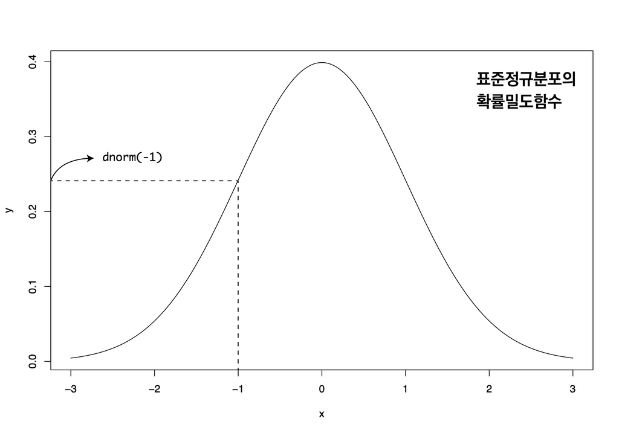

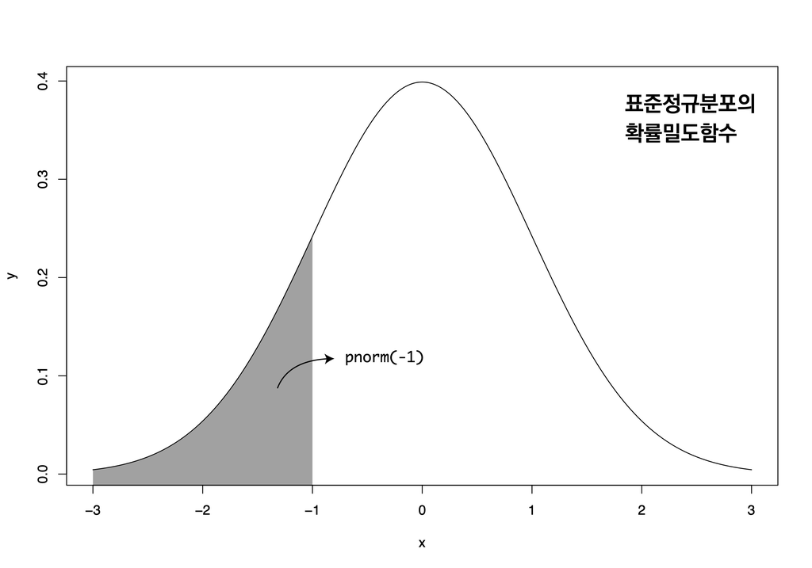

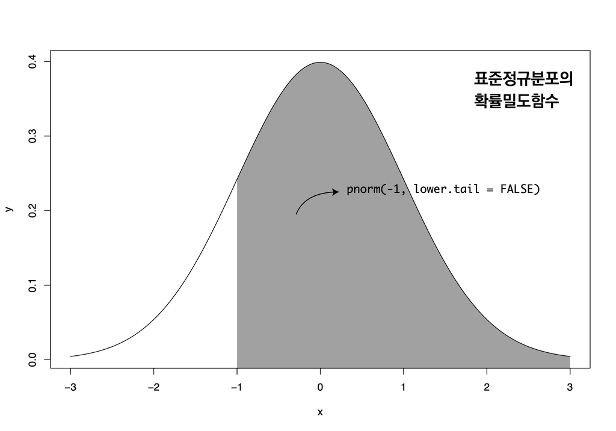

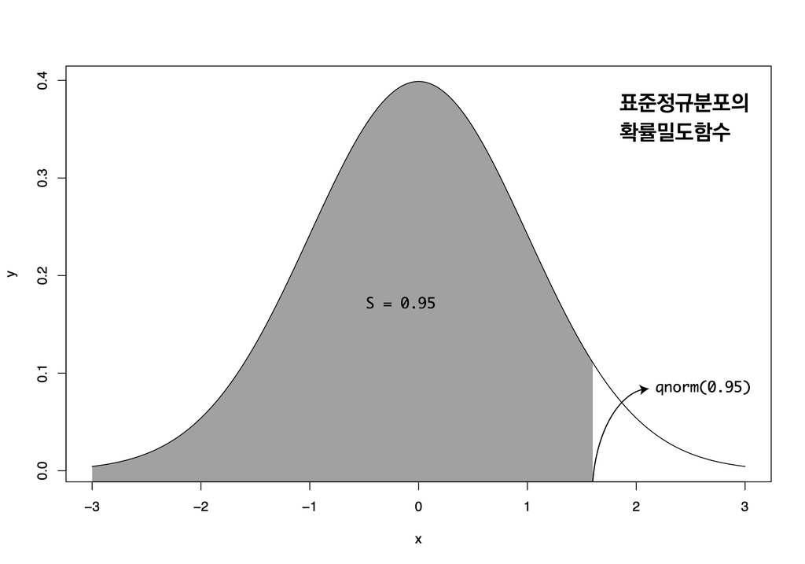

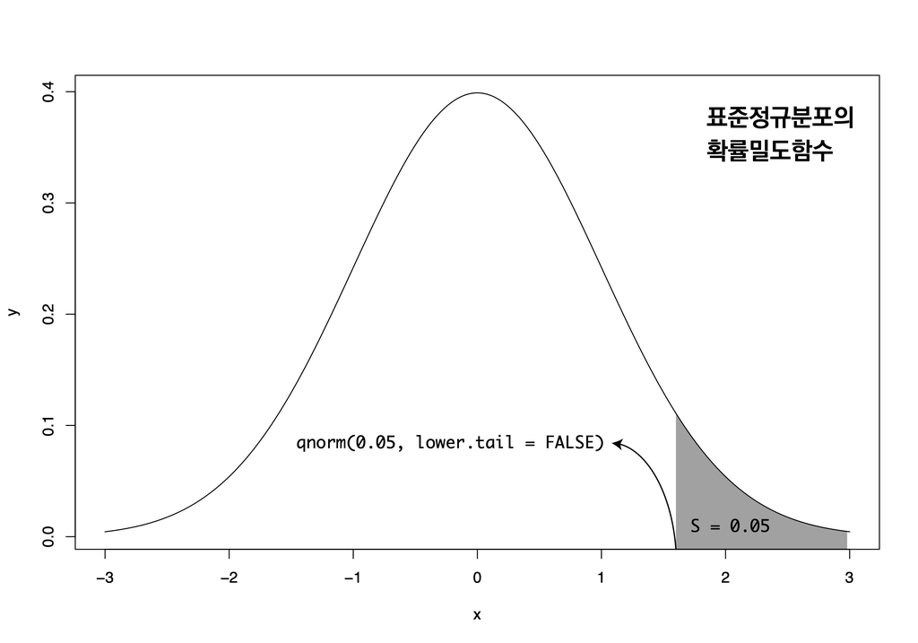

```r
dnorm(-1, mean=0, sd=1)
```

```
## [1] 0.2419707
```

```r
pnorm(-1, mean=0, sd=1)
```

```
## [1] 0.1586553
```

```r
qnorm(0.95, mean=0, sd=1)
```

```
## [1] 1.644854
```

```r
rnorm(3, mean=0, sd=1)
```

```
## [1]  0.7356935 -2.5064365 -0.8175538
```

```r
set.seed(0)
rnorm(3, mean=0, sd=1)
```

```
## [1]  1.2629543 -0.3262334  1.3297993
```

# Simple Linear Regression

Consider a simple linear regression model
$$y_i = \beta_0 + \beta_1 x_i + \epsilon_i, ~
i=1,2,\dots,n,$$
where we assume $\epsilon_i \overset{iid}{\sim} N(0,\sigma^2)$.

Then least square estimator is
$$\hat{\beta}_1 = \frac{S_{xy}}{S_{xx}} , ~ \hat{\beta}_0 = \overline{y} -
\hat{\beta}_1 \overline{x}.$$

- We will use the `Boston` data, which is provided by the **MASS** package. This data records `medv` (median house value) for 506 census tracts. We wish to predict `medv` using `lstat` (percent of lower status of the population) variable.

```r
library(MASS) # MASS packages comes with R and does not require installation.
data(Boston)
head(Boston)
```

```
##      crim zn indus chas   nox    rm  age    dis rad tax ptratio  black lstat
## 1 0.00632 18  2.31    0 0.538 6.575 65.2 4.0900   1 296    15.3 396.90  4.98
## 2 0.02731  0  7.07    0 0.469 6.421 78.9 4.9671   2 242    17.8 396.90  9.14
## 3 0.02729  0  7.07    0 0.469 7.185 61.1 4.9671   2 242    17.8 392.83  4.03
## 4 0.03237  0  2.18    0 0.458 6.998 45.8 6.0622   3 222    18.7 394.63  2.94
## 5 0.06905  0  2.18    0 0.458 7.147 54.2 6.0622   3 222    18.7 396.90  5.33
## 6 0.02985  0  2.18    0 0.458 6.430 58.7 6.0622   3 222    18.7 394.12  5.21
##   medv
## 1 24.0
## 2 21.6
## 3 34.7
## 4 33.4
## 5 36.2
## 6 28.7
```

- `lm` function performs linear regression.

```r
lm.fit <- lm(medv ~ lstat, data = Boston)
lm.fit          # basic information
```

```
##
## Call:
## lm(formula = medv ~ lstat, data = Boston)
##
## Coefficients:
## (Intercept)        lstat
##       34.55        -0.95
```

```r
summary(lm.fit) # detailed information
```

```
##
## Call:
## lm(formula = medv ~ lstat, data = Boston)
##
## Residuals:
##     Min      1Q  Median      3Q     Max
## -15.168  -3.990  -1.318   2.034  24.500
##
## Coefficients:
##             Estimate Std. Error t value Pr(>|t|)
## (Intercept) 34.55384    0.56263   61.41   <2e-16 ***
## lstat       -0.95005    0.03873  -24.53   <2e-16 ***
## ---
## Signif. codes:  0 '***' 0.001 '**' 0.01 '*' 0.05 '.' 0.1 ' ' 1
##
## Residual standard error: 6.216 on 504 degrees of freedom
## Multiple R-squared:  0.5441, Adjusted R-squared:  0.5432
## F-statistic: 601.6 on 1 and 504 DF,  p-value: < 2.2e-16
```

- From the result above, you can find values such as:
  - Least square estimates $\hat\beta_0$ and $\hat\beta_1$ : 34.55 and -0.95.
  - Standard errors of $\hat\beta_0$ and $\hat\beta_1$ : 0.56 and 0.04.
  - t-statistic for testing $H_0: \beta_1 = 0$ : -24.53.
  - p-value of the two-sided test $H_0: \beta_1 = 0$ vs. $H_1: \beta_1 \neq 0$ : smaller than $2\times 10^{-16}$.
  - $\hat\sigma = \sqrt{MS_E} = \sqrt{SS_E/(n-2)}$ : 6.22.
  - Coefficient of determination $R^2$ : 0.5441.
  - F-statistic for testing $H_0: \beta_1 = 0$ and its p-value : 601.6 (this is equivalent to $(-24.53)^2$), p-value is smaller than $2\times 10^{-16}$.
- Although it is not shown explicitly, you can also calculate values such as:
  - Variances of $\hat\beta_0$ and $\hat\beta_1$ : $0.56^2$ and $0.04^2$.
  - Confidence intervals of $\beta_0$ and $\beta_1$ : $\hat\beta_0 \pm t_{\alpha/2, n-2} se(\hat\beta_0)$, and similar for $\beta_1$.
  - Confidence interval of $\sigma^2$.
  - $SS_E$, $SS_T = SS_E/(1-R^2)$, and $SS_R = SS_E\times R^2/(1-R^2)$ (check!).
  - $S_{xy}$, $S_{xx}$ and $S_{yy}$.
- Use the `names` function to find out what kind of information are stored in `lm.fit`. These information can be accessed using the dollar sign or using extractor functions like `coef`.

```r
names(lm.fit)
```

```
##  [1] "coefficients"  "residuals"     "effects"       "rank"
##  [5] "fitted.values" "assign"        "qr"            "df.residual"
##  [9] "xlevels"       "call"          "terms"         "model"
```

```r
lm.fit$coefficients
```

```
## (Intercept)       lstat
##  34.5538409  -0.9500494
```

```r
coef(lm.fit)
```

```
## (Intercept)       lstat
##  34.5538409  -0.9500494
```

- `confint` gives a confidence interval for the coefficient estimates. To produce confidence intervals and prediction intervals for the prediction of `medv`, we can use `predict` function. Observe that prediction intervals are wider than confidence intervals.

```r
confint(lm.fit)
```

```
##                 2.5 %     97.5 %
## (Intercept) 33.448457 35.6592247
## lstat       -1.026148 -0.8739505
```

```r
predict(lm.fit, data.frame(lstat = c(5, 10, 15)), interval="confidence")
```

```
##        fit      lwr      upr
## 1 29.80359 29.00741 30.59978
## 2 25.05335 24.47413 25.63256
## 3 20.30310 19.73159 20.87461
```

```r
predict(lm.fit, data.frame(lstat = c(5, 10, 15)), interval="prediction")
```

```
##        fit       lwr      upr
## 1 29.80359 17.565675 42.04151
## 2 25.05335 12.827626 37.27907
## 3 20.30310  8.077742 32.52846
```

- We can visualize the result using some graphic commands in `R`.

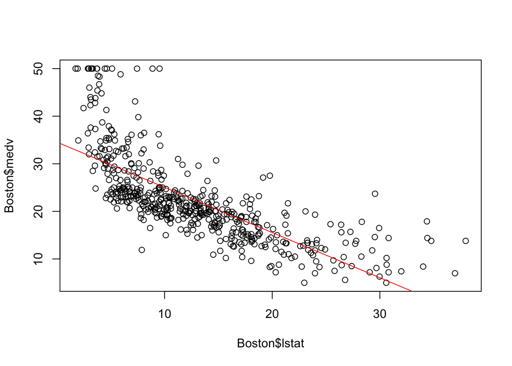

```r
plot(Boston$lstat, Boston$medv)
abline(lm.fit, col = "red")
```

## Simple linear regression from direct calculation

```r
x <- Boston$lstat
y <- Boston$medv
n <- nrow(Boston)
Sxx <- sum((x-mean(x))^2)
Sxy <- sum((x-mean(x))*(y-mean(y)))
beta1.hat <- Sxy/Sxx
beta0.hat <- mean(y) - beta1.hat*mean(x)
beta1.hat; beta0.hat
```

```
## [1] -0.9500494
```

```
## [1] 34.55384
```

### References

- *Introduction to Linear Regression Analysis*, 5th Edition, by Montgomery, Peck & Vining, Wiley (2012).
- *An Introduction to Statistical Learning*, 2nd Edition, by James, Witten, Hastie & Tibshirani, Springer (2021).